# IODS course project

Karoliina Suonpaa

# About the project

This an Introduction to open data science. https://github.com/karosuon/IODS-project

# RStudio Exercise 2

The dataset is a student survey collected by Kimmo Vehkalahti. In the data wrangling exercise, I chose the variables relevant for this assignment: here we have 7 variables and 166 observations. The structure of the dataset is seen below. There are more women than men among the respondents, the median age is 22. Variable “Attitude” measures the students’ attitudes towards statistics. Variables “deep”, “stra”, and “surf” measure the different approaches to learning: The variable “deep” consists of 12 different items measuring the deep approach towards learning, which refers the intention to maximize understanding and a true commitment to learning. The variable “stra” refers to Strategic approach and it consists of 8 different items. It measures the way students organize their studing. Lastly, variable “surf” refers to Surface approach and consists of 12 different items measuring memorizing without understanding, with a serious lack of personal engagement in the learning proces. The variable “Points” measures the students’ success at the exam. Students who received 0 points were omitted from the study.

```r
  setwd("Z:/Jatko-opinnot/Tilastotiede 2016/IODS/IODS-project")
  new_data <- read.csv("learning2014.csv", sep=",", header=T)
```

```r
#check the data
  str(new_data)
```

```
## 'data.frame':    166 obs. of  8 variables:
##  $ X       : int  1 2 3 4 5 6 7 8 9 10 ...
##  $ gender  : Factor w/ 2 levels "F","M": 1 2 1 2 2 1 2 1 2 1 ...
##  $ Age     : int  53 55 49 53 49 38 50 37 37 42 ...
##  $ Attitude: int  37 31 25 35 37 38 35 29 38 21 ...
##  $ deep    : int  43 35 42 42 44 57 46 39 52 48 ...
##  $ stra    : int  27 22 29 25 29 29 18 32 34 28 ...
##  $ surf    : int  30 43 31 25 36 30 31 36 33 38 ...
##  $ Points  : int  25 12 24 10 22 21 21 31 24 26 ...
```

```r
  summary(new_data)
```

```
##        X          gender       Age           Attitude          deep
##  Min.   :  1.00   F:110   Min.   :17.00   Min.   :14.00   Min.   :19.00
##  1st Qu.: 42.25   M: 56   1st Qu.:21.00   1st Qu.:26.00   1st Qu.:40.00
##  Median : 83.50           Median :22.00   Median :32.00   Median :44.00
##  Mean   : 83.50           Mean   :25.51   Mean   :31.43   Mean   :44.16
##  3rd Qu.:124.75           3rd Qu.:27.00   3rd Qu.:37.00   3rd Qu.:49.00
##  Max.   :166.00           Max.   :55.00   Max.   :50.00   Max.   :59.00
##       stra            surf           Points
##  Min.   :10.00   Min.   :19.00   Min.   : 7.00
##  1st Qu.:21.00   1st Qu.:31.00   1st Qu.:19.00
##  Median :25.50   Median :35.00   Median :23.00
##  Mean   :24.97   Mean   :35.45   Mean   :22.72
##  3rd Qu.:29.00   3rd Qu.:41.00   3rd Qu.:27.75
##  Max.   :40.00   Max.   :56.00   Max.   :33.00
```

```r
 #install and access the GGally and ggplot2 libraries
    install.packages("GGally", repos="http://cran.rstudio.com/")
    install.packages("ggplot2", repos="http://cran.rstudio.com/")
    library(ggplot2)
    library(GGally)
```

```r
#get a graphical overview of the data
  p_new_data <- ggpairs(new_data, mapping = aes(col = gender, alpha=0.3), lower = list(combo = wrap("facethist", bins = 20)))
```

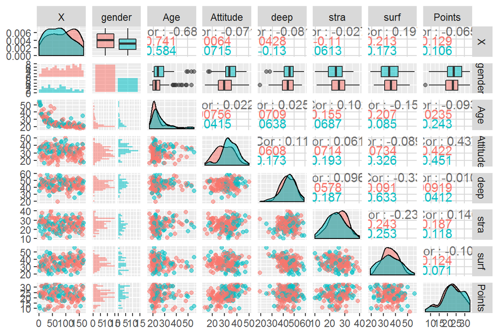

```r
  #print the picture
p_new_data
```

This plot is a neat way of examining the data: we see the correlations and distributions for both genders. From the upper row we see that the male students are in average a bit older than the female students, and they also seem to have a more positive attitude towards statistics. The gender differences between the the different learning approaches (deep and surface learning) seem really small. Female students seem to be a bit more strategic learnings. Male students seem to get slightly better points from the test. All in all, the distributions seem pretty similar for both of the genders. Most of these bivariate correlations seem to be pretty small, but the strongest correlation we see between the attitude and poins (0.44), and the surface and deep learning (-0.33), and strategic and surface learning (-0.24). I do not know the theory behind the survey but it seems reasonable, that deep and surface learning have negative correlation.

```r
#fit to the linear model
lin_reg <- lm(Points ~ Attitude + stra + surf, data = new_data)
  summary(lin_reg)
```

```
##
## Call:
## lm(formula = Points ~ Attitude + stra + surf, data = new_data)
##
## Residuals:
##      Min       1Q   Median       3Q      Max
## -17.0460  -3.4408   0.4437   3.5871  10.7946
##
## Coefficients:
##             Estimate Std. Error t value Pr(>|t|)
## (Intercept) 10.41431    3.57084   2.916  0.00404 **
## Attitude     0.34419    0.05681   6.059 9.28e-09 ***
## stra         0.10551    0.06882   1.533  0.12720
## surf        -0.03242    0.05944  -0.545  0.58625
## ---
## Signif. codes:  0 '***' 0.001 '**' 0.01 '*' 0.05 '.' 0.1 ' ' 1
##
## Residual standard error: 5.3 on 162 degrees of freedom
## Multiple R-squared:  0.2063, Adjusted R-squared:  0.1916
## F-statistic: 14.03 on 3 and 162 DF,  p-value: 3.543e-08
```

Next I excluded the variable which had the highest p-value and the smallest estimate, the surface learning.

```r
  #fit to the linear model
lin_reg2 <- lm(Points ~ Attitude + stra, data = new_data)
  summary(lin_reg2)
```

```
##
## Call:
## lm(formula = Points ~ Attitude + stra, data = new_data)
##
## Residuals:
##      Min       1Q   Median       3Q      Max
## -17.6436  -3.3113   0.5575   3.7928  10.9295
##
## Coefficients:
##             Estimate Std. Error t value Pr(>|t|)
## (Intercept)  8.97290    2.39591   3.745  0.00025 ***
## Attitude     0.34658    0.05652   6.132 6.31e-09 ***
## stra         0.11421    0.06681   1.709  0.08927 .
## ---
## Signif. codes:  0 '***' 0.001 '**' 0.01 '*' 0.05 '.' 0.1 ' ' 1
##
## Residual standard error: 5.289 on 163 degrees of freedom
## Multiple R-squared:  0.2048, Adjusted R-squared:  0.1951
## F-statistic: 20.99 on 2 and 163 DF,  p-value: 7.734e-09
```

Here, we have only two independent variables: attitude towards statistics and stratetic learning. The estimates of the independent variable are slightly bigger than in previous model, and the degrees of freedom increased by one. The attitude has again statistically significant correlation with the points, stategic learning has not. Hende, I exclude also the stategic learning from the model.

```r
lin_reg3 <- lm(Points ~ Attitude, data = new_data)
  summary(lin_reg3)
```

```
##
## Call:
## lm(formula = Points ~ Attitude, data = new_data)
##
## Residuals:
##      Min       1Q   Median       3Q      Max
## -16.9763  -3.2119   0.4339   4.1534  10.6645
##
## Coefficients:
##             Estimate Std. Error t value Pr(>|t|)
## (Intercept) 11.63715    1.83035   6.358 1.95e-09 ***
## Attitude     0.35255    0.05674   6.214 4.12e-09 ***
## ---
## Signif. codes:  0 '***' 0.001 '**' 0.01 '*' 0.05 '.' 0.1 ' ' 1
##
## Residual standard error: 5.32 on 164 degrees of freedom
## Multiple R-squared:  0.1906, Adjusted R-squared:  0.1856
## F-statistic: 38.61 on 1 and 164 DF,  p-value: 4.119e-09
```

In my final model there is only one explanatory factor: the attitude. When the attitude towards statistics increases by one unit, the average change in the points is 0.35 units. Multiple R-squared tells how much of the variance in the dependent variable can be explained by the independent variables. This model explains 19 % of the variation in the dependent variable (the points from the exam). Every time we add an independent variable to the model, the R-squared value will increase. Yet, we do not know if the increase in R-squared value is caused by the actual predictive power of the new variable, or just by chance alone.Adjusted R-squared provides the same information as R-squared but adjusts for the number of terms in the model. It decreases when the new variable does not have any real impact on the predicted value. (In this assingment, they are almost the same because we do not have many variables.)

Linear model have several assumptions, and how well the model describes the phenomenon we are studying, depends on how well these assumptions fit the reality. It is assumed that (1) the relationship between the independent and dependent variable is linear, (2) that the errors are normally distributed, (3) not correlated, and (4) have a constant variance. Prediction errors are called residuals and the model is found by minimizing the sum of residuals. Hence, analyzing the residuals of the model is a good method for analyzing the validity of the assumptions.

QQ-plot is a method for studying the normality assumption. The better the points fit into the line, the better the fit with the normality assumption. In this picture we see that the majority of the observations fit to the normality assumption, only a few extreme values have weaker fit. Yet, the perfect fit can only be found with the synthetic data and I think our dataset passes this test.

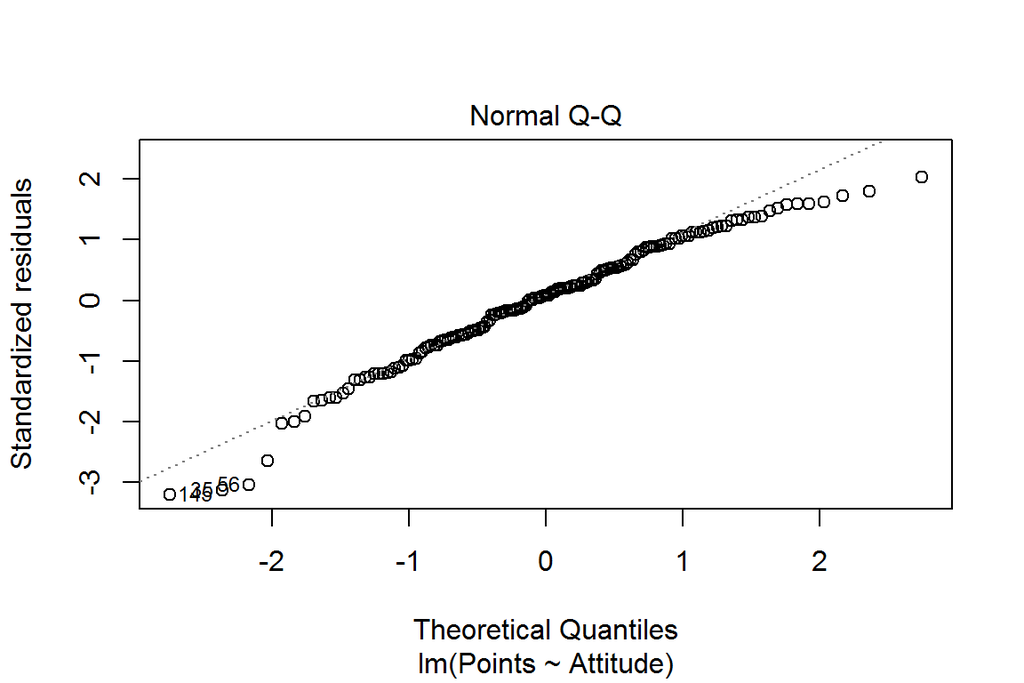

```r
plot(lin_reg3, which=c(2))
```

The constant variance assumption implies that the size of the errors should not depend on the explanatory variables. This is explored with a scatter plot of residuals versus model predictions. In the picture, residuals seem to be quite evenly distributed, we do not see any patterns in the picture but the spread of the dots seems reasonable random.

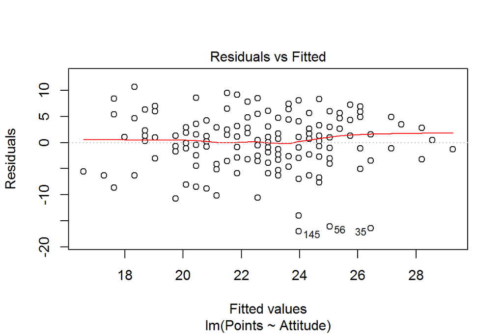

```r
plot(lin_reg3, which=c(1))
```

Leverage measures the impact of a single observation to the model.Residuals vs leverage plot can help identify which observations have an usually high impact. There does not seem to be a problem with the leverage: no single outliers are having too much leverage to the model.

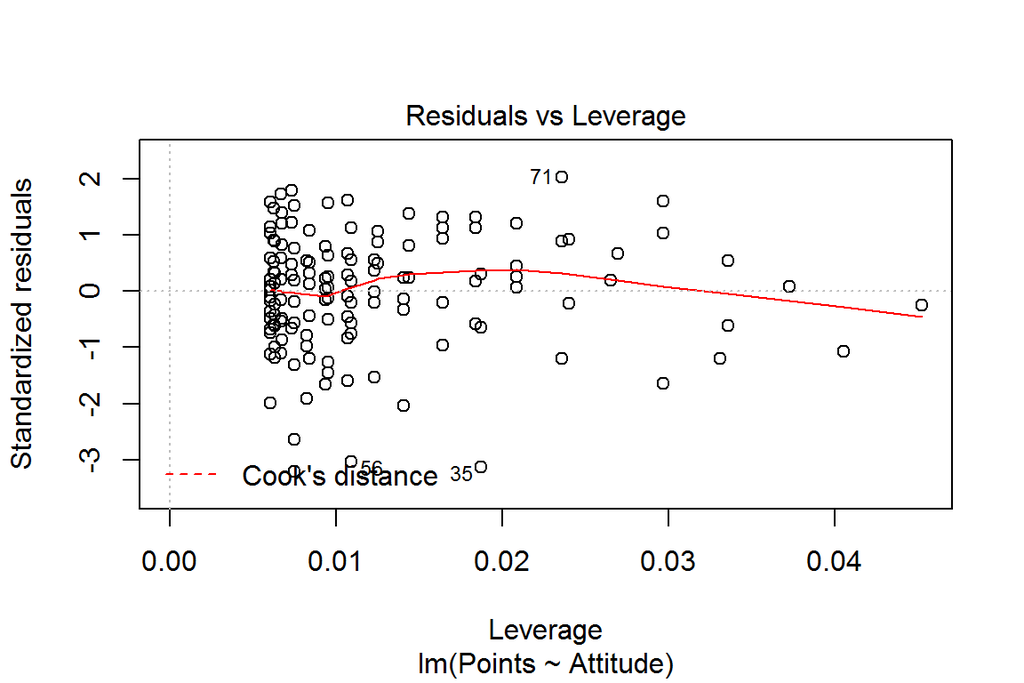

```r
plot(lin_reg3, which=c(5))
```

Based on these diagnostic pictures, the linear model seems to fit the dataset.

# RStudio Exercise 3

```r
  setwd("Z:/Jatko-opinnot/Tilastotiede 2016/IODS/IODS-project")
  uci <- read.csv("http://s3.amazonaws.com/assets.datacamp.com/production/course_2218/datasets/alc.txt ", sep=",", header=T)
```

This dataset is retrieved from the UCI Machine Learning Repository which is a source for open data. The data contain two identical questionnaires related to secondary school student alcohol comsumption in Portugal. For this exercise, two surveys were combined to one dataset. This final dataset contains 382 observations and 35 variables describing the participants and their families. More information about the data can be found here: https://archive.ics.uci.edu/ml/datasets/STUDENT+ALCOHOL+CONSUMPTION.

```r
#check the data
dim(uci)
```

```
## [1] 382  35
```

```r
names(uci)
```

```
##  [1] "school"     "sex"        "age"        "address"    "famsize"
##  [6] "Pstatus"    "Medu"       "Fedu"       "Mjob"       "Fjob"
## [11] "reason"     "nursery"    "internet"   "guardian"   "traveltime"
## [16] "studytime"  "failures"   "schoolsup"  "famsup"     "paid"
## [21] "activities" "higher"     "romantic"   "famrel"     "freetime"
## [26] "goout"      "Dalc"       "Walc"       "health"     "absences"
## [31] "G1"         "G2"         "G3"         "alc_use"    "high_use"
```

My hypothesis is that sex, the quality of family relationships, the amount of staying out with friends, and a will to go to higher education are associated to alcohol consumption in the following ways:

Hypothesis 1: Boys tend drink more alcohol than girls. Hypothesis 2: Students who have bad relationship with their family, tend to drink more alcohol. Hypothesis 3: Student who go out with friends a lot, tend to drink more alcohol. Hypothesis 4: Students who want to continue to higher education, tend to drink less alcohol.

From the picture below we notice that most of the participants describe their alcohol consumtion as very low.

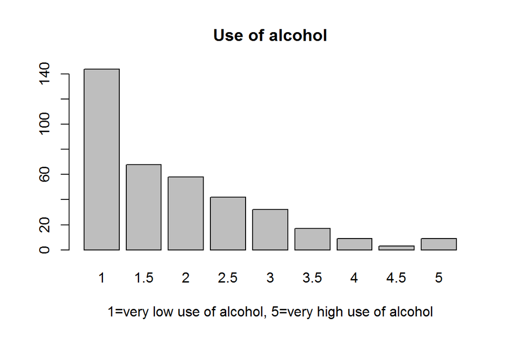

```r
#barplots describing the use of alcohol
counts <- table(uci$alc_use)
barplot(counts, main="Use of alcohol", xlab="1=very low use of alcohol, 5=very high use of alcohol")
```

In some analysis I will use the dummy variable where students are divided between those who use a lot of alcohol (higher than 2 in a scale from 1 to 5) and those who do not. In our dataset, 112 of 382 students drink a lot of alcohol.

```r
summary(uci$high_use)
```

```
##    Mode   FALSE    TRUE    NA's
## logical     270     112       0
```

There are 198 girls and 184 boys in our dataset. My first hypothesis concerned the association of sex and the use of alcohol. From the boxplot below we see that boys tend to drink more than girls. However, there seems to be a lot of distribution among both of the sexes.

```r
summary(uci$sex)
```

```
##   F   M
## 198 184
```

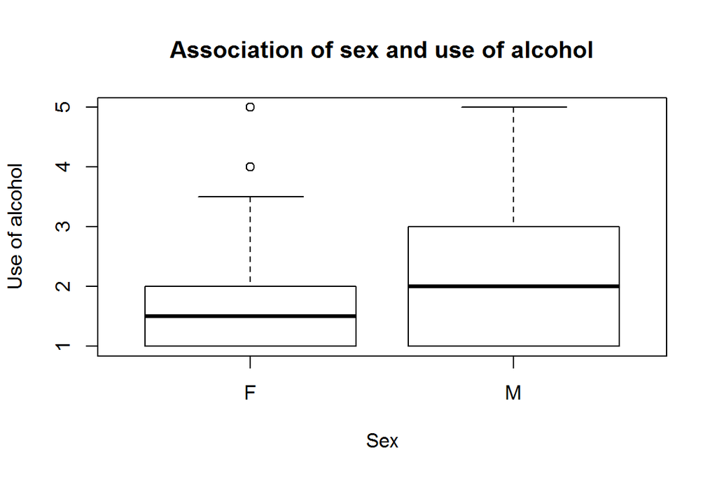

```r
boxplot(alc_use~sex, data=uci, main="Association of sex and use of alcohol", xlab="Sex", ylab="Use of alcohol")
```

I wanted to examine the association with the cross-tabulation also. In the cross-table below I used the dummy variable describing the high use of alcohol. We see again that high use of alcohol is more common among boys.

```r
#install and use the package
install.packages("gmodels", repos="http://cran.rstudio.com/")
library(gmodels)
```

```r
CrossTable(uci$high_use, uci$sex)
```

```
##
##
##    Cell Contents
## |-------------------------|
## |                       N |
## | Chi-square contribution |
## |           N / Row Total |
## |           N / Col Total |
## |         N / Table Total |
## |-------------------------|
##
##
## Total Observations in Table:  382
##
##
##              | uci$sex
## uci$high_use |         F |         M | Row Total |
## -------------|-----------|-----------|-----------|
##        FALSE |       157 |       113 |       270 |
##              |     2.078 |     2.236 |           |
##              |     0.581 |     0.419 |     0.707 |
##              |     0.793 |     0.614 |           |
##              |     0.411 |     0.296 |           |
## -------------|-----------|-----------|-----------|
##         TRUE |        41 |        71 |       112 |
##              |     5.009 |     5.390 |           |
##              |     0.366 |     0.634 |     0.293 |
##              |     0.207 |     0.386 |           |
##              |     0.107 |     0.186 |           |
## -------------|-----------|-----------|-----------|
## Column Total |       198 |       184 |       382 |
##              |     0.518 |     0.482 |           |
## -------------|-----------|-----------|-----------|
##
##
```

I also tested the correlation between sex and the use of alcohol. It is statistically significant (p<0.001) but not very strong.

```r
#transform categorical variable to numeric
uci$sex_num<-as.numeric(uci$sex)
#get correlation
cor.test (uci$alc_use, uci$sex_num, alternative = c ("two.sided"))
```

```
##
##  Pearson's product-moment correlation
##
## data:  uci$alc_use and uci$sex_num
## t = 5.6177, df = 380, p-value = 3.745e-08
## alternative hypothesis: true correlation is not equal to 0
## 95 percent confidence interval:
##  0.1816222 0.3670529
## sample estimates:
##       cor
## 0.2769136
```

My second hypothesis concerned the association of the quality of family relationship and the use of alcohol.I assume that bad relationship with family is associated with the higher use of alcohol. Most of the participants seem to have a good relationship with their family.

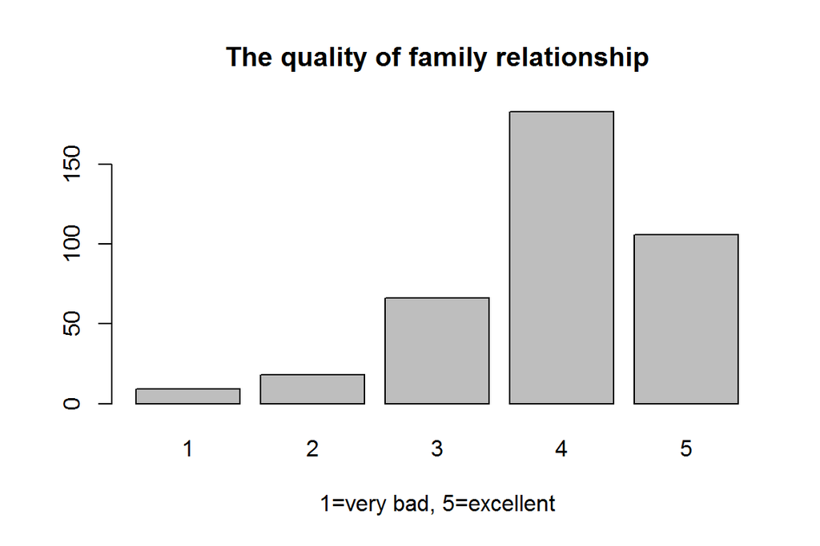

```r
counts2 <- table(uci$famrel)
barplot(counts2, main="The quality of family relationship", xlab="1=very bad, 5=excellent")
```

In the boxplot below we see the association of the use of alcohol and the quality of family relationship.The quality of family relationship was coded the way that bigger the value, the better the relationship (1=very low, 5=excellent). The relationship does not seem clear: there are some outliers and it seems that both the groups that have either very bad (1) or excellent (5) relationship with their families drink less than some groups in the middle.

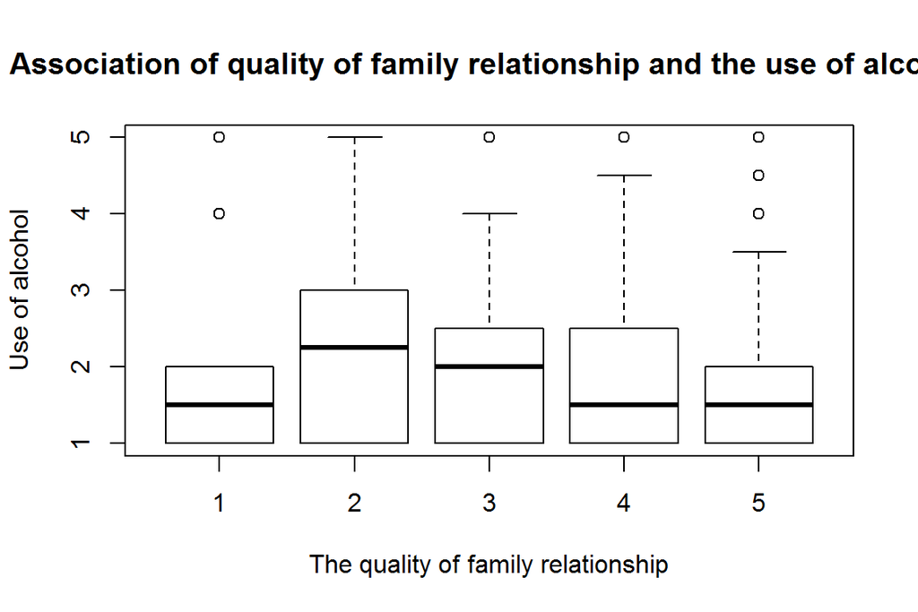

```r
boxplot(alc_use~famrel, data=uci, main="Association of quality of family relationship and the use of alcohol", xlab="The quality of family relationship", ylab="Use of alcohol")
```

I tested the correlation between the quality of family relationship and use of alcohol. It is statistically significant (p<0.05) but very small. The direction is what I assumed: weak relationship with family is associated with increased alcohol consumption.

```r
cor.test (uci$alc_use, uci$famrel, alternative = c ("two.sided"))
```

```
##
##  Pearson's product-moment correlation
##
## data:  uci$alc_use and uci$famrel
## t = -2.3683, df = 380, p-value = 0.01837
## alternative hypothesis: true correlation is not equal to 0
## 95 percent confidence interval:
##  -0.21830113 -0.02051548
## sample estimates:
##       cor
## -0.120605
```

My third hypothesis was that going out with friends is positively associated with the use of alcohol. Going out was coded so that greater the value, the more often the participant goes out with friends. Only a small proportion of the participants were going out very rarely.

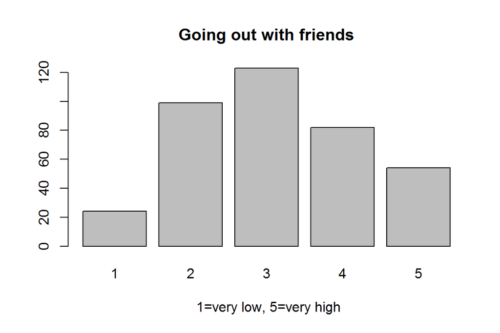

```r
counts3 <- table(uci$goout)
barplot(counts3, main="Going out with friends", xlab=" 1=very low, 5=very high")
```

In the boxplot below we see that going out with friends is associated with the use of alcohol: those who go out the most, also drink the most.

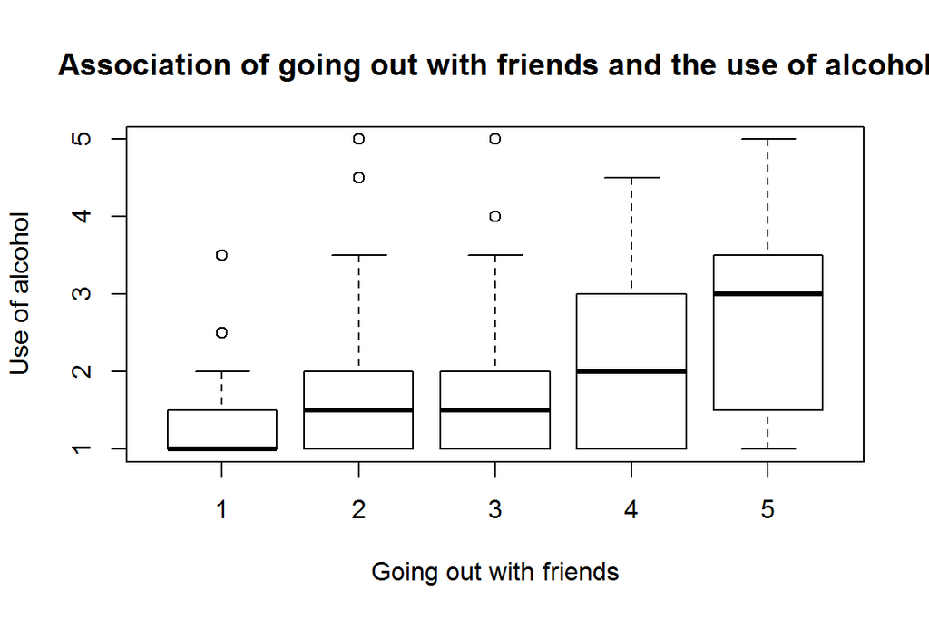

```r
boxplot(alc_use~goout, data=uci, main="Association of going out with friends and the use of alcohol", xlab="Going out with friends", ylab="Use of alcohol")
```

I wanted to examine this association with the cross-tabulations also. In the cross-table below, I used again the dummy variable describing the high use of alcohol. We see that in the groups of the students who go out the most (5), 59 % of the students drink a lot of alcohol, compared 19 % of those students go out an average amount (3), or 13 % of students who go out the least (1).

```r
CrossTable(uci$high_use, uci$goout)
```

```
##
##
##    Cell Contents
## |-------------------------|
## |                       N |
## | Chi-square contribution |
## |           N / Row Total |
## |           N / Col Total |
## |         N / Table Total |
## |-------------------------|
##
##
## Total Observations in Table:  382
##
##
##              | uci$goout
## uci$high_use |         1 |         2 |         3 |         4 |         5 | Row Total |
## -------------|-----------|-----------|-----------|-----------|-----------|-----------|
##        FALSE |        21 |        84 |       100 |        43 |        22 |       270 |
##              |     0.961 |     2.812 |     1.963 |     3.860 |     6.848 |           |
##              |     0.078 |     0.311 |     0.370 |     0.159 |     0.081 |     0.707 |
##              |     0.875 |     0.848 |     0.813 |     0.524 |     0.407 |           |
##              |     0.055 |     0.220 |     0.262 |     0.113 |     0.058 |           |
## -------------|-----------|-----------|-----------|-----------|-----------|-----------|
##         TRUE |         3 |        15 |        23 |        39 |        32 |       112 |
##              |     2.316 |     6.778 |     4.732 |     9.306 |    16.510 |           |
##              |     0.027 |     0.134 |     0.205 |     0.348 |     0.286 |     0.293 |
##              |     0.125 |     0.152 |     0.187 |     0.476 |     0.593 |           |
##              |     0.008 |     0.039 |     0.060 |     0.102 |     0.084 |           |
## -------------|-----------|-----------|-----------|-----------|-----------|-----------|
## Column Total |        24 |        99 |       123 |        82 |        54 |       382 |
##              |     0.063 |     0.259 |     0.322 |     0.215 |     0.141 |           |
## -------------|-----------|-----------|-----------|-----------|-----------|-----------|
##
##
```

I tested also the correlation between going out with friends and drinking alcohol. Just like I assumed, there is adequate and statistically significant (p<0.001) correlation between the amount of going out with friends and the use of alcohol.

```r
cor.test (uci$alc_use, uci$goout, alternative = c ("two.sided"))
```

```
##
##  Pearson's product-moment correlation
##
## data:  uci$alc_use and uci$goout
## t = 8.2071, df = 380, p-value = 3.561e-15
## alternative hypothesis: true correlation is not equal to 0
## 95 percent confidence interval:
##  0.2993426 0.4700625
## sample estimates:
##       cor
## 0.3880259
```

My last hypothesis was that students who want to continue to higher education tend to drink less alcohol. Overwhelming majority of the participants want to continue to higher education.

```r
summary(uci$higher)
```

```
##  no yes
##  18 364
```

In the boxplot we see that the average use of alcohol seem to be higher among the students who do not want to continue to higher education.

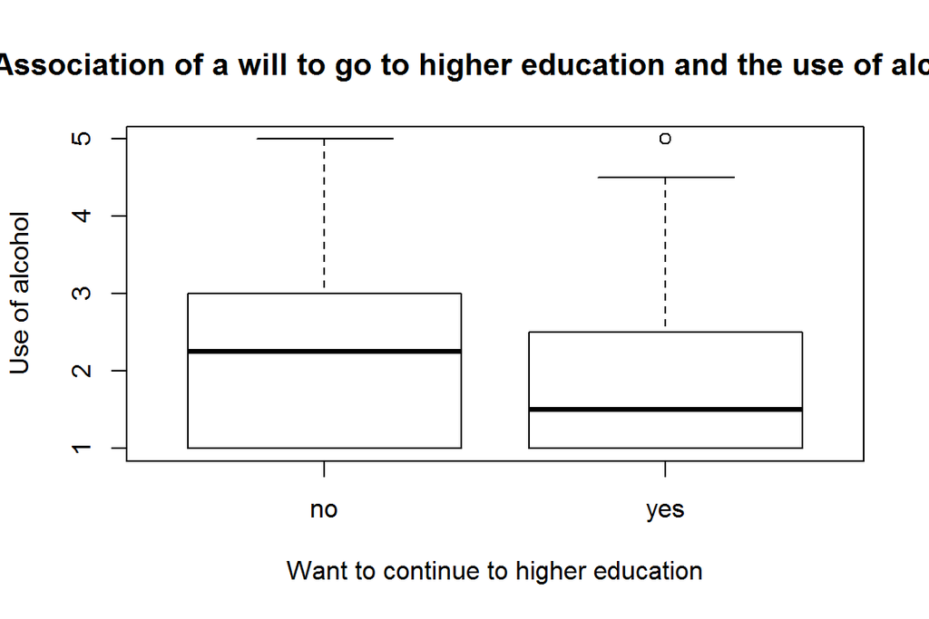

```r
boxplot(alc_use~higher, data=uci, main="Association of a will to go to higher education and the use of alcohol", xlab="Want to continue to higher education", ylab="Use of alcohol")
```

I tested the associaton of the will to go to higher education and high use of alcohol also with a crosstable where I again used the dummy variable describing the high use of alcohol.The students who no not want to continue to higher education are distributed evenly to both groups of drinking (high use and not high use), but a clear majority (72 %) of students who want to continue to higher education are not drinking a lot of alcohol.

```r
CrossTable(uci$high_use, uci$higher)
```

```
##
##
##    Cell Contents
## |-------------------------|
## |                       N |
## | Chi-square contribution |
## |           N / Row Total |
## |           N / Col Total |
## |         N / Table Total |
## |-------------------------|
##
##
## Total Observations in Table:  382
##
##
##              | uci$higher
## uci$high_use |        no |       yes | Row Total |
## -------------|-----------|-----------|-----------|
##        FALSE |         9 |       261 |       270 |
##              |     1.089 |     0.054 |           |
##              |     0.033 |     0.967 |     0.707 |
##              |     0.500 |     0.717 |           |
##              |     0.024 |     0.683 |           |
## -------------|-----------|-----------|-----------|
##         TRUE |         9 |       103 |       112 |
##              |     2.626 |     0.130 |           |
##              |     0.080 |     0.920 |     0.293 |
##              |     0.500 |     0.283 |           |
##              |     0.024 |     0.270 |           |
## -------------|-----------|-----------|-----------|
## Column Total |        18 |       364 |       382 |
##              |     0.047 |     0.953 |           |
## -------------|-----------|-----------|-----------|
##
##
```

The correlation between the use of alcohol and a will to go to higher education is very small and the p-value gets close the common threshold for statistical significance (p = 0.06). Dataset does not support my fourth hypothesis. However, the number of students who do not want to continue to higher education was very small (only 18 students) so maybe there were not enough variance for studying this association.

```r
uci$higher_num<-as.numeric(uci$higher)
cor.test (uci$alc_use, uci$higher_num, alternative = c ("two.sided"))
```

```
##
##  Pearson's product-moment correlation
##
## data:  uci$alc_use and uci$higher_num
## t = -1.8923, df = 380, p-value = 0.05921
## alternative hypothesis: true correlation is not equal to 0
## 95 percent confidence interval:
##  -0.195064144  0.003756883
## sample estimates:
##         cor
## -0.09661735
```

Next I test my previous hypothesis with logistic regression.

```r
#install and use the package
install.packages("dplyr", repos="http://cran.rstudio.com/")
library(dplyr)
```

```r
logreg <- glm(high_use ~ sex + famrel + goout + higher, data = uci, family = "binomial")
summary(logreg)
```

```
##
## Call:
## glm(formula = high_use ~ sex + famrel + goout + higher, family = "binomial",
##     data = uci)
##
## Deviance Residuals:
##     Min       1Q   Median       3Q      Max
## -1.5567  -0.7651  -0.5030   0.8407   2.5719
##
## Coefficients:
##             Estimate Std. Error z value Pr(>|z|)
## (Intercept)  -1.7123     0.8405  -2.037 0.041630 *
## sexM          0.9248     0.2572   3.595 0.000324 ***
## famrel       -0.4657     0.1383  -3.366 0.000762 ***
## goout         0.8008     0.1217   6.581 4.68e-11 ***
## higheryes    -0.4956     0.5729  -0.865 0.387071
## ---
## Signif. codes:  0 '***' 0.001 '**' 0.01 '*' 0.05 '.' 0.1 ' ' 1
##
## (Dispersion parameter for binomial family taken to be 1)
##
##     Null deviance: 462.21  on 381  degrees of freedom
## Residual deviance: 386.79  on 377  degrees of freedom
## AIC: 396.79
##
## Number of Fisher Scoring iterations: 4
```

Above we see the results of a logistic regression where the high use of alcohol is a dependent variable and sex, the quality of family relationship, the amount of going out with friends and will to continue to higher education are independent variables.As stated above, sex is associated with the high use of alcohol: boys tend to drink more alcohol. (Sex is a categorial variable and R orders the levels of the categorial variable alphabetically and takes the first as reference class. Hence, girls are here the reference class.) The quality of family relationship has an inverse association to the high use of alcohol. Going out with friends is positively associated with the high use of alcohol. Instead, the will to continue to higher education is not statistically significantly associated with the high use of alcohol. (Here the reference class is those who do not want to continue to higher education.)

```r
#odds ratios and the confidence intervalls (95 %)
OR <- coef(logreg) %>% exp
CI <- confint(logreg) %>% exp
#print out the odds ratios with their confidence intervals (95 %)
cbind(OR, CI)
```

```
##                    OR      2.5 %   97.5 %
## (Intercept) 0.1804536 0.03317016 0.908224
## sexM        2.5212955 1.53110552 4.206039
## famrel      0.6276752 0.47666182 0.821350
## goout       2.2274018 1.76685208 2.850085
## higheryes   0.6092337 0.19534256 1.892822
```

Above we see the odds ratios and confidence intervals (95 %). Boys have a higher odds of the high use of alcohol than girs (OR=2.5, CI=1.5-4.2). Yet, confidence intervalls are quite wide. However, this finding clearly supports the first hypothesis. The quality of the family relationship is inversely associated with a high use of alcohol (OR=0.6, CI=0.5-0.8): the better the relationship, the smaller the odds of a high use of alcohol. The association is not very strong, though, since the coefficient is quite small. However, this finding supports the second hypothesis. Going out with friends is associated with the high use of alcohol (OR=2.2, CI=1.8-2.9). Hence, also the third hypothesis is clearly supported by the model. A will to continue to higher education seems to be associated with the high use of alcohol in a hypothesized way: the odds for those who want to go to higher education is less than 1 (OR=0.6, CI=0.2-1.9). However, the confidence interval is huge so I conclude that the fourth hypothesis does not get support from the data. It seems that of the variables I studies, going out with friends is the best predictor of the high use of alcohol. It sounds logical: for many young people, drinking alcohol is related to social situations, such as going out with peers.

I test the predictive power of my model by calculating the proportion of correctly classified observations. The proportion of inccorrectly classified observations is the error of my model. I include only the variables wchich had a statistical relationship with high alcohol consumption according to my logistic regression model, hence I exclude the variable describing the will to continue to higher education.

```r
#fit the model again, without the variable "higher"
logreg2 <- glm(high_use ~ sex + famrel + goout, data = uci, family = "binomial")
#predict the probability of high use of alcohol
probabilities <- predict(logreg2, type = "response")
#add the predicted probabilities to dataset
uci <- mutate(uci, probability = probabilities)
#use the probabilities to make a prediction of high use of alcohol
uci <- mutate(uci, prediction = probability >0.5 )
```

In the cross table below we see the confusion matrix comparing the real and the predicted model. My model seems to underestimate the amount of students who use a lot of alcohol.

```r
table(high_use = uci$high_use, prediction = uci$prediction) %>% prop.table() %>% addmargins()
```

```
##         prediction
## high_use      FALSE       TRUE        Sum
##    FALSE 0.65706806 0.04973822 0.70680628
##    TRUE  0.16230366 0.13089005 0.29319372
##    Sum   0.81937173 0.18062827 1.00000000
```

In the plot below, the probability is on the x axis and the high use of alcohol is on the y axis.

```r
#use the package
library(ggplot2)
```

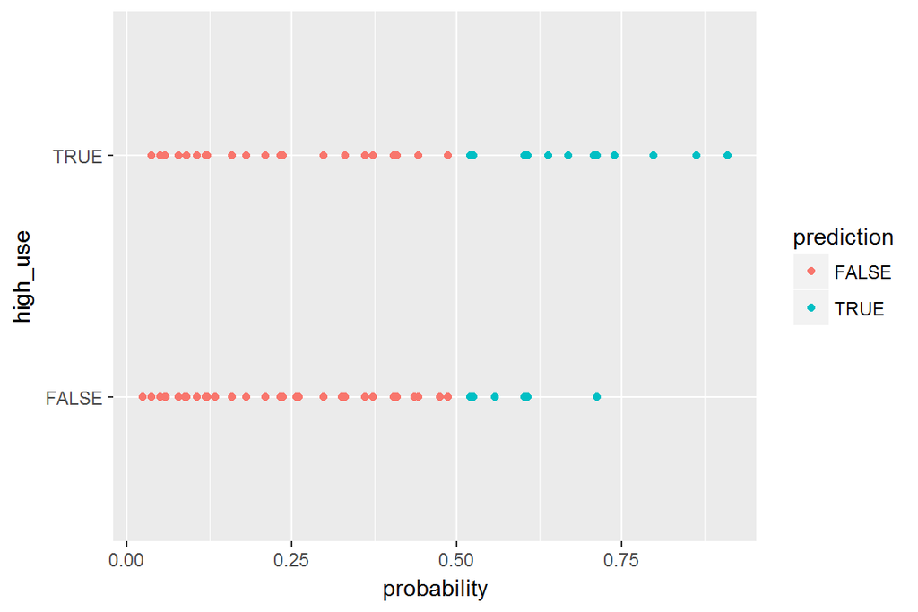

```r
g1 <- ggplot(uci, aes(x = probability, y = high_use, col=prediction))
g1 + geom_point()
```

Next I define a loss function and compute the mean prediction error for my model.

```r
#define a loss function (mean prediction error)
loss_func <- function(class, prob) {
  n_wrong <- abs(class - prob) > 0.5
  mean(n_wrong)
}
```

```r
#call loss_func to compute the average number of wrong predictions in the (training) data
loss_func(class = uci$high_use, prob = uci$probability)
```

```
## [1] 0.2120419
```

We see that the training error of the model is 0.21. It means that, on average, 21 % of the predictions were wrong. Simple guessing method in a binary situation (e.g. flipping a symmetric coin) would have been right roughly in 50 % of the events. My model predicted accurately in 79 % of situations. Hence, my model performed better than just guessing.

As a bonus, I perform 10-fold cross-validation on my model. Cross-validation involves partitioning a sample of data into complementary subsets, performing the analysis on one subset (“the training set”), and validating the analysis on the other subset (“the testing set”). The process is repeated so that eventually all of the data is used for both the training and testing.

```r
#install and use the package
install.packages("boot", repos="http://cran.rstudio.com/")
library(boot)
```

```r
#perform 10-fold cross-validation by using earlier created loss function
cv <- cv.glm(data = uci, cost = loss_func, glmfit = logreg2, K = 10)
```

Delta gives two values: The first component is the raw cross-validation estimate of prediction error. The second component is the adjusted cross-validation estimate. The adjustment is designed to compensate for the bias introduced by not using leave-one-out cross-validation.

```r
#Print out the mean prediction error for the testing data.
cv$delta
```

```
## [1] 0.2172775 0.2138373
```

The training error estimated from the whole dataset was 21 %. The testing error is roughly 22 %. It means that my model accurately predicted 78 % of the observations in the testing set. The error is a slightly smaller than in the Datacamp exercise (0.26).

```r
  setwd("Z:/Jatko-opinnot/Tilastotiede 2016/IODS/IODS-project")
```